# NYC 2015 Tree Census

The NYC 2015 tree census has been done every 10 years since 1995, which records the location, size, species, and condition of all public street and park trees in New York City.

For the park trees, it involves volunteers from NYC that are trained on-site, and for the street trees, it uses cars with mounted devices that collect information on the trees.

Let’s first import our data set, and load the Tidyverse package for ggplot, we will get our data from the NYC OpenData website:

https://data.cityofnewyork.us/Environment/2015-Street-Tree-Census-Tree-Data/uvpi-gqnh/about_data

```r
# Import data set
Tree_Data <- read.csv("C:/Users/gabox/OneDrive/Desktop/UKY Classes/Projects/NYC 2015 Tree Census/2015_Street_Tree_Census_-_Tree_Data_20251025.csv")

# Install Tidyverse
options(repos = c(CRAN = "https://cran.rstudio.com"))
install.packages("tidyverse")
# Load Tidyverse package
library(tidyverse)
```

From the description of the project on the website, some of its goals are:

- Understand the characteristics of the Urban forest’s population in NYC.
- Understand the change over time of the urban forest in NYC.
- Develop new management and operational plans for all trees across the city.
- Identify areas where there is room for more trees.

Since one of the goals of the study is to understand the characteristics of the Urban forest’s population in NYC, my goal will be to create a plot that shows some of these characteristics.

Let’s use the head() function to see what kind of information we have available in the data set.

```r
# First 6 rows in tree data set
head(Tree_Data)
```

|  | tree_id | block_id | created_at | tree_dbh | stump_diam | curb_loc | status | health | spc_latin | spc_common | steward | guards | sidewalk | user_type | problems | root_stone | root_grate | root_other | trunk_wire | trnk_light | trnk_other | brch_light | brch_shoe | brch_other | address | postcode | zip_city | community.board | borocode | … |
| --- | --- | --- | --- | --- | --- | --- | --- | --- | --- | --- | --- | --- | --- | --- | --- | --- | --- | --- | --- | --- | --- | --- | --- | --- | --- | --- | --- | --- | --- | --- |
| 1 | 180683 | 348711 | 08/27/2015 | 3 | 0 | OnCurb | Alive | Fair | Acer rubrum | red maple | None | None | NoDamage | TreesCount Staff | None | No | No | No | No | No | No | No | No | No | 108-005 70 AVENUE | 11375 | Forest Hills | 406 | 4 | … |
| 2 | 200540 | 315986 | 09/03/2015 | 21 | 0 | OnCurb | Alive | Fair | Quercus palustris | pin oak | None | None | Damage | TreesCount Staff | Stones | Yes | No | No | No | No | No | No | No | No | 147-074 7 AVENUE | 11357 | Whitestone | 407 | 4 | … |
| 3 | 204026 | 218365 | 09/05/2015 | 3 | 0 | OnCurb | Alive | Good | Gleditsia triacanthos var. inermis | honeylocust | 1or2 | None | Damage | Volunteer | None | No | No | No | No | No | No | No | No | No | 390 MORGAN AVENUE | 11211 | Brooklyn | 301 | 3 | … |
| 4 | 204337 | 217969 | 09/05/2015 | 10 | 0 | OnCurb | Alive | Good | Gleditsia triacanthos var. inermis | honeylocust | None | None | Damage | Volunteer | Stones | Yes | No | No | No | No | No | No | No | No | 1027 GRAND STREET | 11211 | Brooklyn | 301 | 3 | … |
| 5 | 189565 | 223043 | 08/30/2015 | 21 | 0 | OnCurb | Alive | Good | Tilia americana | American linden | None | None | Damage | Volunteer | Stones | Yes | No | No | No | No | No | No | No | No | 603 6 STREET | 11215 | Brooklyn | 306 | 3 | … |
| 6 | 190422 | 106099 | 08/30/2015 | 11 | 0 | OnCurb | Alive | Good | Gleditsia triacanthos var. inermis | honeylocust | 1or2 | Helpful | NoDamage | Volunteer | None | No | No | No | No | No | No | No | No | No | 8 COLUMBUS AVENUE | 10023 | New York | 107 | 1 | … |

I can see on the data set that the tree species are recorded under “spc_common”. Since this study wants to better understand the characteristic of the trees in NYC, I want to show the characteristics of some of the specifies of trees. Let’s take a look at how many tree species are in our data set:

```r
# Number of species of trees in the data
length(unique(Tree_Data$spc_common))
```

```
## [1] 133
```

I see that there’s a total of 133 species of trees in the data. I will select the 5 most common species of trees in the data set for our plot. Let’s first see which are the most common species.

```r
Tree_Data %>%
  # Group by the species
  group_by(spc_common) %>%
  # Count totals for each group
  count() %>%
  # Arrange by most to least common
  arrange(desc(n)) %>%
  # Show only the first 5 rows
  head(n = 5)
```

| spc_common | n |
| --- | --- |
| London planetree | 87014 |
| honeylocust | 64264 |
| Callery pear | 58931 |
| pin oak | 53185 |
| Norway maple | 34189 |

Now I will create a new data set by filtering our data so that it contains only the 5 most common species.

```r
# Vector of 5 most common tree species
common_species <- c("London planetree", "honeylocust", "Callery pear", "pin oak", "Norway maple")

# New data set
Tree_Data_spc <- Tree_Data %>%
  # Include only 5 most common tree species
  filter(spc_common == common_species)
```

Now that we have our data with only the 5 most common species, let’s look at some of the characteristics of these species.

I want to look the the average of the diameter at breast height for each of the 5 species of trees in our data set, and see how this diameter differs according to the borough or city of NYC the tree is located at.

In our data set, diameters at breast height are recorded under “tree_dbh”, cities are recorded under “zip_city”, and the boroughs are recorded under “borough”.

Let’s first check how many boroughs and cities there are at NYC.

```r
# Number of boroughs in NYC
length(unique(Tree_Data_spc$borough))
```

```
## [1] 5
```

```r
# Number of cities in NYC
length(unique(Tree_Data_spc$zip_city))
```

```
## [1] 47
```

We see that there’s only 5 boroughs compared to 47 cities. I will use boroughs in my plot for the sake of simplicity, and so that we can take into consideration every single tree of each species in the data set.

Now let’s plot our data.

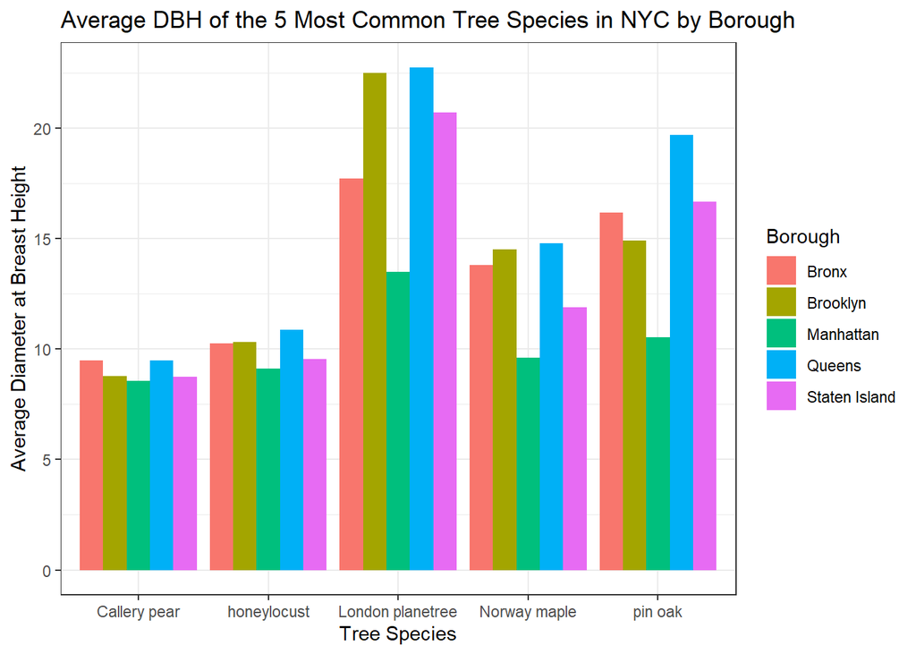

```r
Tree_Data_spc %>%
  # Group by the tree species and borough of NYC
  group_by(spc_common, borough) %>%
  # Calculate average diameter at breast height
  summarise(mean_dbh = mean(tree_dbh, na.rm = TRUE)) %>%
  # Plot data
  ggplot(aes(
    # Tree species displayed at x-axis
    x = spc_common,
    # Average diameter at breast height displayed in y-axis
    y = mean_dbh,
    # Borough represented by bar color
    fill = borough)
    ) +
  # Place bars of tree species by boroughs
  geom_col(position = "dodge") +
  # Change theme to black and white
  theme_bw() +
  # Change x label
  xlab("Tree Species") +
  # Change y label
  ylab("Average Diameter at Breast Height") +
  # Add title
  ggtitle("Average DBH of the 5 Most Common Tree Species in NYC by Borough") +
  # Change legend title
  labs(fill = "Borough")
```

Looking at our plot, we can see that the London planetree species has the highest average DBH out of all tree species, with the Callery pear species having the lowest average DBH out of all species.

We can also see that the trees at Queens tend to have the highest average DBH for all species of trees, with the trees at Manhattan having the lowest average DBH out of all boroughs of NYC.

Finally, the Callery pear’s average DBH was the most consistent among boroughs, with the London planetree having the highest variation by location.

Something to note here is that the London plane species had the highest average DBH and the Callery pear had the lowest, so it seems as though the lower a tree specie’s average DBH is, the less its DBH will vary by different locations, in this case the borough.